# Predicting Unsolved Homicides (1976-2024)

#### `Agentype` by `Solved`

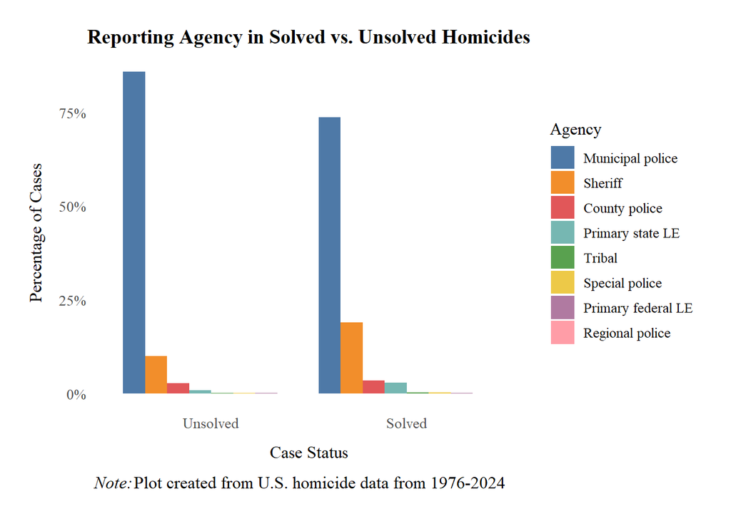

```r
data_agentype <- data %>%
  group_by(Solved, Agentype) %>%
  summarise(Count = n(), .groups = "drop") %>%
  group_by(Solved) %>%
  mutate(Proportion = Count / sum(Count),
         Agentype = fct_reorder(Agentype, Proportion, .desc = TRUE))

ggplot(data_agentype, aes(x = Solved, y = Proportion, fill = Agentype)) +
  geom_bar(stat = "identity", position = position_dodge(width = 0.9)) +
  scale_fill_custom +
  scale_y_continuous(labels = scales::percent) +
  labs(title = "Reporting Agency in Solved vs. Unsolved Homicides",
       x = "Case Status",
       y = "Percentage of Cases",
       fill = "Agency",
       caption = expression(paste(italic("Note:"), "Plot created from U.S. homicide data from 1976-2024")))
```

#### `VicAge_Missing`

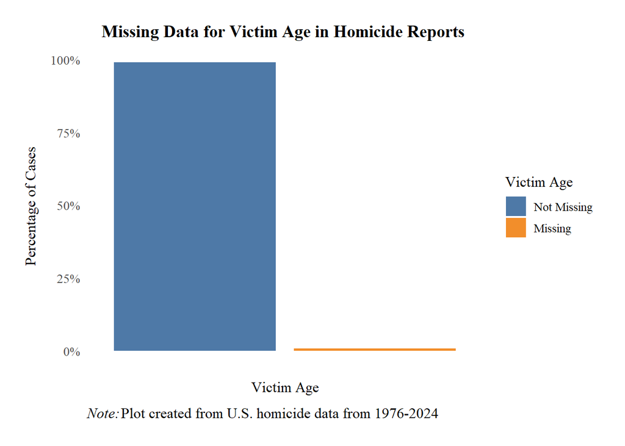

```r
data_vicage_missing <- data %>%
  group_by(VicAge_Missing) %>%
  summarise(Proportion = n()/nrow(data), .groups = "drop") %>%
  mutate(VicAge_Missing = fct_reorder(VicAge_Missing, Proportion, .desc = TRUE))

ggplot(data_vicage_missing, aes(x = VicAge_Missing, y = Proportion, fill = VicAge_Missing)) +
  geom_bar(stat = "identity") +
  scale_fill_custom +
  scale_y_continuous(labels = scales::percent) +
  labs(title = "Missing Data for Victim Age in Homicide Reports ",
       x = "Victim Age",
       y = "Percentage of Cases",
       fill = "Victim Age",
       caption = expression(paste(italic("Note:"), "Plot created from U.S. homicide data from 1976-2024"))) +
  theme(axis.text.x = element_blank())
```

#### `VicAge_Missing` by `Solved`

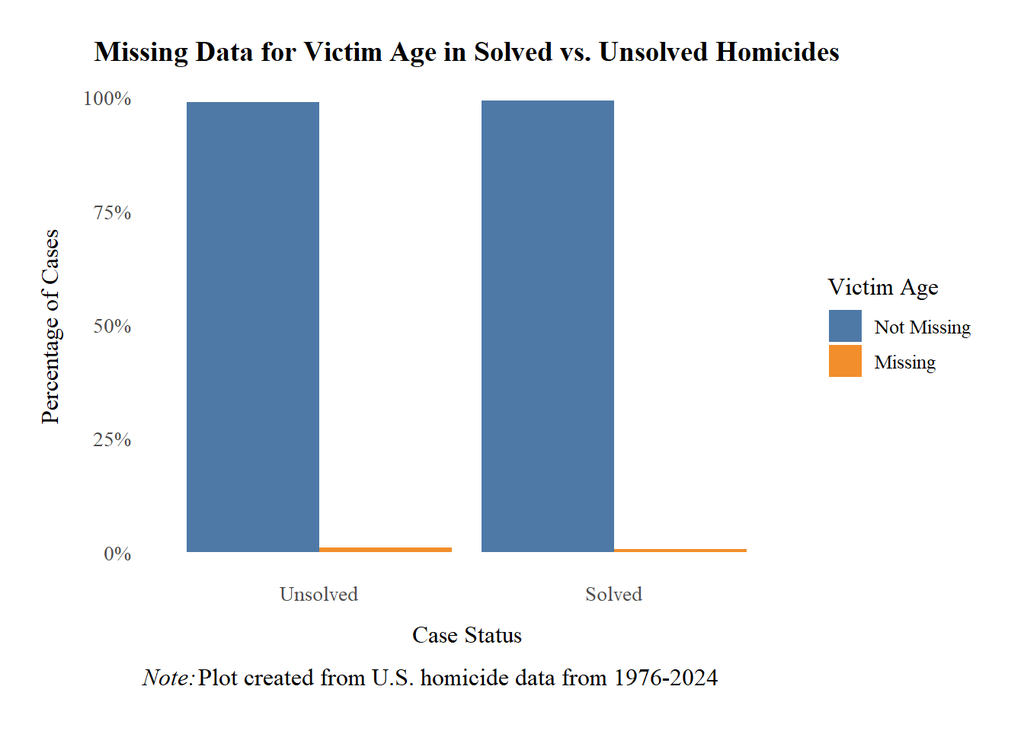

```r
data_vicage_missing <- data %>%
  group_by(Solved, VicAge_Missing) %>%
  summarise(Count = n(), .groups = "drop") %>%
  group_by(Solved) %>%
  mutate(Proportion = Count / sum(Count),
         VicAge_Missing = fct_reorder(VicAge_Missing, Proportion, .desc = TRUE))

ggplot(data_vicage_missing, aes(x = Solved, y = Proportion, fill = VicAge_Missing)) +
  geom_bar(stat = "identity", position = position_dodge(width = 0.9)) +
  scale_fill_custom +
  scale_y_continuous(labels = scales::percent) +
  labs(title = "Missing Data for Victim Age in Solved vs. Unsolved Homicides",
       x = "Case Status",
       y = "Percentage of Cases",
       fill = "Victim Age",
       caption = expression(paste(italic("Note:"), "Plot created from U.S. homicide data from 1976-2024")))
```

#### `OffAge_Missing`

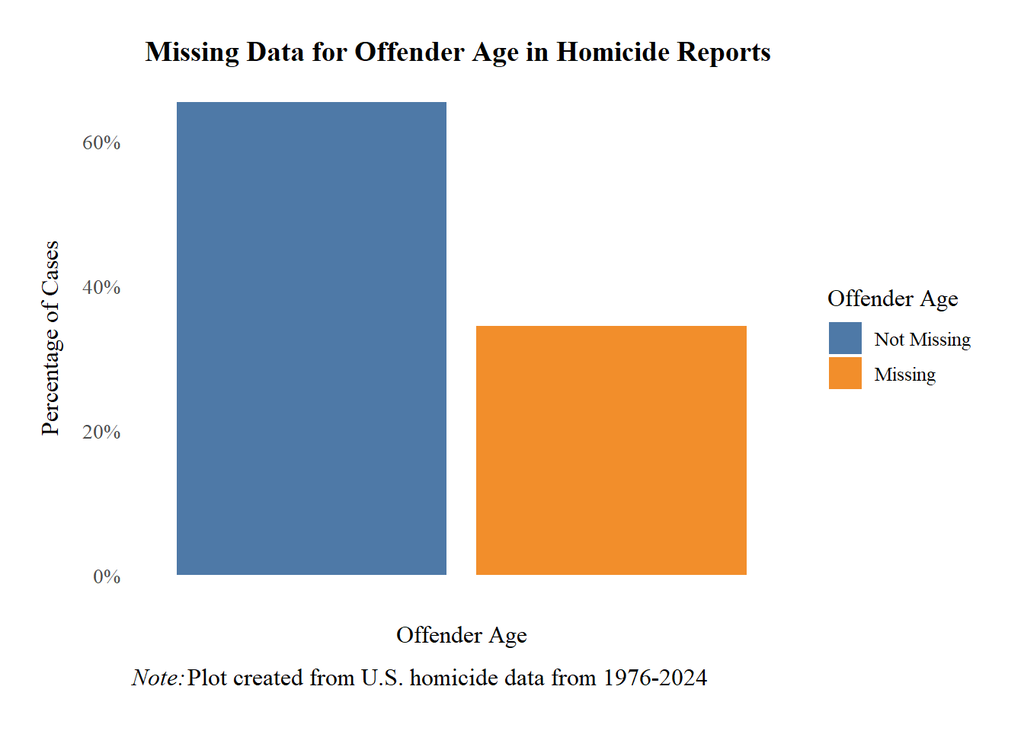

```r
data_offage_missing <- data %>%
  group_by(OffAge_Missing) %>%
  summarise(Proportion = n()/nrow(data), .groups = "drop") %>%
  mutate(OffAge_Missing = fct_reorder(OffAge_Missing, Proportion, .desc = TRUE))

ggplot(data_offage_missing, aes(x = OffAge_Missing, y = Proportion, fill = OffAge_Missing)) +
  geom_bar(stat = "identity") +
  scale_fill_custom +
  scale_y_continuous(labels = scales::percent) +
  labs(title = "Missing Data for Offender Age in Homicide Reports ",
       x = "Offender Age",
       y = "Percentage of Cases",
       fill = "Offender Age",
       caption = expression(paste(italic("Note:"), "Plot created from U.S. homicide data from 1976-2024"))) +
  theme(axis.text.x = element_blank())
```

#### `OffAge_Missing` by `Solved`

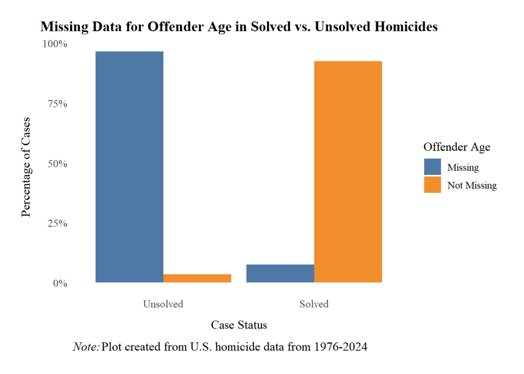

```r
data_offage_missing <- data %>%
  group_by(Solved, OffAge_Missing) %>%
  summarise(Count = n(), .groups = "drop") %>%
  group_by(Solved) %>%
  mutate(Proportion = Count / sum(Count),
         OffAge_Missing = fct_reorder(OffAge_Missing, Proportion, .desc = TRUE))

ggplot(data_offage_missing, aes(x = Solved, y = Proportion, fill = OffAge_Missing)) +
  geom_bar(stat = "identity", position = position_dodge(width = 0.9)) +
  scale_fill_custom +
  scale_y_continuous(labels = scales::percent) +
  labs(title = "Missing Data for Offender Age in Solved vs. Unsolved Homicides",
       x = "Case Status",
       y = "Percentage of Cases",
       fill = "Offender Age",
       caption = expression(paste(italic("Note:"), "Plot created from U.S. homicide data from 1976-2024")))
```

## Modelling

After some consideration, I chose to use random forest modelling to create a classification model for predicting whether a given homicide case would be solved.

Several factors contributed to this decision. Initially, I planned to use a logistic regression model to predict case status (i.e., solved vs. unsolved) from the predictors listed in the project introduction.

However, several factors led me to believe that this may not be an appropriate choice of model. First, it was evident to me that an NHST approach would be largely pointless given the extremely large sample size (i.e., *n* = 874,958). As such, it would be necessary to rely on effect sizes to provide any kind of conclusions about the importance of a given predictor in a relative (i.e., comparing predictors) or practical manner.

Furthermore, a preliminary exploration of the research literature indicated that there was little relevant empirical research into the research question that I selected. This meant that I had no a priori grounds for selecting predictor variables (aside from their availability in the dataset) nor for assuming that the relationship between a given predictor and the outcome was linear. It seemed possible to me that the relationship between predictors and the outcome might be interactive or nonlinear, but I had no literature that would enable me to stipulate these relationships ahead of time using previous data or theory.

Relatedly, a deeper review of the dataset indicated that several of the categorical variables (e.g., `Weapon`, `Relationship`) had a large number of levels. This would make it difficult to disentangle the value of each level of these variables in the prediction of whether a homicide case will be solved. Two approaches for partially addressing this obstacle would be to conceptually simplify levels (e.g., aggregating `relationship` levels such as girlfriend, boyfriend, husband, wife into an overarching “partner” level) or eliminate less common levels. However, both of these approaches would require some kind of a priori knowledge to do so responsibly.

Finally, the ultimate goal of the project was to provide a *useful* model for predicting the likely case status of future cases. Hypothetically, this model would help law enforcement officials make decisions in terms of prioritization and resource allocation in future murder cases. For instance, if a future homicide case was predicted to be unsolved by the model, law enforcement officials could allocate a greater number of personnel to investigating it or have research-based grounds for petitioning for additional resources from other law enforcement bodies (e.g., municipal or tribal police requesting aid from state or federal bodies). This indicated that the primary goal of the model was *predictive* rather than explanatory.

Given these considerations, a machine learning (ML) model seemed most apt for this particular research question. I had a classification problem where I was interested in maximizing the predictive value of the model. Furthermore, I had no grounds for selecting, modifying, or interpreting the predictors of the outcome variable. While I was interested in the relative importance of predictors (and their levels), this would be more elegantly achieved in a ML model than in a logistic regression model. In particular, I believed a random forest model would answer the research question in the most effective and practically useful way possible.

### Step 1: Selecting Model Features

The results of the EDA conducted previously indicate that some of the variables may be inappropriate for predictive modelling. Specifically, some variables occurred in unsolved cases almost 100% of the time and occurred far less frequently in solved cases. The following variables displayed this tendency:

- `OffAge` (in particular, `NA` values)
- `OffSex` (in particular, the “Unknown” level);
- `OffRace` (in particular, the “Unknown” level);
- `OffEthnic` (in particular, the “Unknown” level);
- `Relationship` (in particular, the “Relationship not determined” level);
- `OffAge_Missing` (in particular, the “Missing” level)

In essence, these variables reflect whether an offender has been identified or apprehended, which is very close to the outcome that I am trying to predict (i.e., `Solved`). Case reports that are unsolved will, for all intents and purposes, *always* lack information regarding the offender *until* they are solved.

This is problematic for several reasons. Statistically, these variables act as a reliable cue for the model to predict case status solely based on this set of variables. As such, the aforementioned variables can be argued to be “proxies” for the outcome variable (i.e., whether a homicide case will be solved). This artificially increases the accuracy of model classification.

From a theoretical perspective, this is also problematic. The inclusion of the aforementioned variables introduces a tautology into prediction, insofar as proxies of the outcome are included as predictors of the outcome. In essence, the model is trying to predict an outcome that it already “knows” from the outset (e.g., “I predict that this case will be unsolved because variable *x* says that it is unsolved”). While random forest models are not designed to have an underlying causal structure (e.g., predictor *x* has an effect on outcome *y*), this is certainly problematic from an applied perspective.

In this vein, the inclusion of these variables limits the utility of this model in terms of predicting novel cases. The primary use case for this project was to provide law enforcement officials (LEOs) with a useful resource that would provide an empirically derived probability that a homicide case would be solved based on information that would be available to LEOs early on in the investigation (e.g., what kind of weapon was used, victim sex). Features that are dependent on case resolution status, such as details about the offender, would not be available at this stage and would thus be irrelevant to the model’s intended use.

Based on these factors, I made the decision to drop these features from the random forest model.

```r
# using dplyr to select the variables to be used in modelling

data <- data %>%
  select(-c(OffAge, OffSex, OffRace, OffEthnic, Relationship, OffAge_Missing))
```

### Step 2: Splitting Data into Training and Testing Sets

Next, I split the data into training and testing sets using the 80/20 rule (i.e., 80% of the data was retained for training and 20% was held out for testing). This allows me to evaluate whether the model will generalize to unseen data. I used the `rsample` package (a part of the `tidymodels` ecosystem)

```r
set.seed(123) # setting seed for reproducibility

data_split <- initial_split(
  data,
  prop = 0.8, # 80% of the data will be used for training
  strata = Solved # stratified sampling based on Solved to ensure roughly equal proportions in train/test data
)

train_data <- training(data_split) # extracting training set data
test_data <- testing(data_split) # extracting testing set data
```

### Step 3: Model Specification and Workflow Creation

I am using the `tidymodels` workflow to implement my machine learning (ML) algorithm. This provides a cohesive ecosystem for building, tuning, and evaluating models within *R*. As I have processed my data in previous steps and conducted my EDA, I can start by creating my model specification in the package.

```r
# using the `rand_forest` function in `parsnip` for model specification
rf_spec <- rand_forest(
  mode = "classification", # indicating that this is a classification problem
  trees = 500, # specifying the number of decision trees
  mtry = tune(), # tuning the number of predictors sampled at splits
  min_n = tune() # tuning the minimum node size for splits
) %>%
  set_engine(
    "ranger", # using the `ranger` engine as it is faster
     importance = "impurity" # calculating feature importance using impurity reduction
  )

# creating a workflow object
rf_workflow <- workflow() # initializing an empty workflow

# adding model and formula to workflow

rf_workflow <- rf_workflow %>%
  add_model(rf_spec) # adding model to workflow

# adding formula to workflow

rf_workflow <- rf_workflow %>%
  add_formula(Solved ~ .)
```

### Step 4: Tuning Hyperparameters

To tune the hyperparameters, I will be using 5-fold cross-validation (courtesy of `rsample`) to identify the values for `mtry`, and `min_n` that produces a model with the best fit for the data.

```r
cv_folds <- vfold_cv( # defining resampling process for cross-validation
  train_data, # specifiying the training data for construction of cross-validation folds
  v = 5, # using 5 cv folds
  strata = Solved # stratified sampling by Solved to ensure similar class distribution
)

rf_grid <- grid_random( # defining a grid of hyperparameters to test
  mtry(range = c(2, 10)), # range of mtry values
  min_n(range = c(5, 25)), # range of min_n values
  size = 20 # sampling 20 random combinations
)

num_cores <- detectCores() - 1 # designating an object with 1 less core than is on my computer

cl <- makeCluster(num_cores) # setting up a cluster for parallel processing
registerDoParallel(cl) # beginning parallel processing

tuned_results <- tune_grid( # initial tuning of hyperparameters using the tune package
  rf_workflow, # inserting workflow with random forest model
  resamples = cv_folds, # resampling according to the cv_folds object
  grid = rf_grid, # using the previously defined grid
  metrics = metric_set(roc_auc, sensitivity, specificity) # using the auc, sensitivity, and specificity to compare tunings
)

stopCluster(cl) # stopping use of cluster
registerDoSEQ() # going back to sequential processing

tuning_summary <- collect_metrics(tuned_results) # using the collect_metrics function to format results

tuning_summary %>% # visualizing tuning results by hyperparameter
  filter(.metric == "roc_auc") %>% # filtering results by auc
  arrange(desc(mean)) # arranging in descending order
```

```
# A tibble: 18 × 8
    mtry min_n .metric .estimator  mean     n std_err .config
   <int> <int> <chr>   <chr>      <dbl> <int>   <dbl> <chr>
 1     3    10 roc_auc binary     0.845     5 0.00211 Preprocessor1_Model11
 2     4    22 roc_auc binary     0.845     5 0.00194 Preprocessor1_Model14
 3     3    19 roc_auc binary     0.845     5 0.00192 Preprocessor1_Model06
 4     3    21 roc_auc binary     0.845     5 0.00199 Preprocessor1_Model08
 5     3    23 roc_auc binary     0.845     5 0.00196 Preprocessor1_Model02
 6     5    24 roc_auc binary     0.844     5 0.00189 Preprocessor1_Model09
 7     6    22 roc_auc binary     0.843     5 0.00185 Preprocessor1_Model16
 8     5    13 roc_auc binary     0.843     5 0.00200 Preprocessor1_Model13
 9     6    21 roc_auc binary     0.843     5 0.00188 Preprocessor1_Model17
10     5    12 roc_auc binary     0.843     5 0.00185 Preprocessor1_Model04
11     7    22 roc_auc binary     0.843     5 0.00188 Preprocessor1_Model03
12     7    19 roc_auc binary     0.842     5 0.00190 Preprocessor1_Model07
13     8    22 roc_auc binary     0.842     5 0.00185 Preprocessor1_Model18
14     2     8 roc_auc binary     0.841     5 0.00222 Preprocessor1_Model10
15     2     9 roc_auc binary     0.841     5 0.00220 Preprocessor1_Model05
16    10    22 roc_auc binary     0.841     5 0.00184 Preprocessor1_Model12
17     8    11 roc_auc binary     0.839     5 0.00187 Preprocessor1_Model01
18     9     7 roc_auc binary     0.836     5 0.00187 Preprocessor1_Model15
```

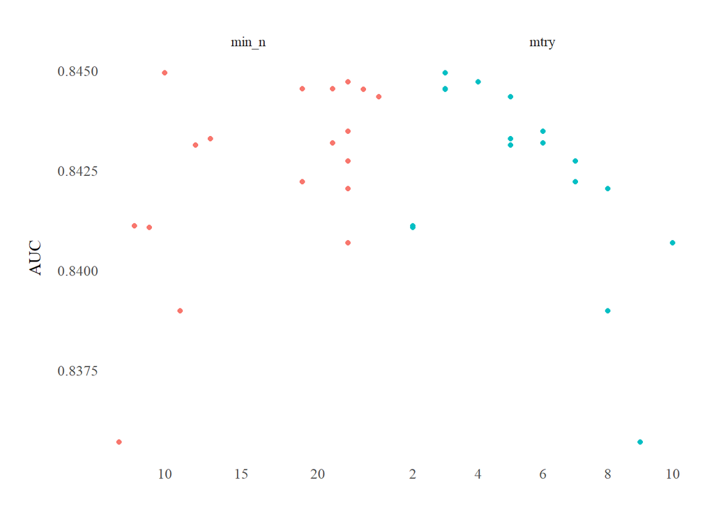

```r
tuned_results %>%
  collect_metrics() %>% # using collect_metrics to format results
  filter(.metric == "roc_auc") %>% # filtering by auc
  select(mean, mtry, min_n) %>% # selecting important variables
  pivot_longer(mtry:min_n, # pivoting for plotting
               values_to = "value",
               names_to = "parameter") %>%
  ggplot(aes(value, mean, color = parameter)) + # using a faceted scatter plot
  geom_point(show.legend = FALSE) +
  facet_wrap(~ parameter, scales = "free_x") +
  labs(x = NULL, y = "AUC")
```

```r
rf_spec <- rand_forest( # updating model specification
  mode = "classification",
  trees = 500,  # Set the number of trees
  mtry = tune(),
  min_n = tune()
) %>%
  set_engine(
    "ranger",
    importance = "impurity")

rf_workflow <- rf_workflow %>%
  update_model(rf_spec) # updating workflow with new model spec

targeted_grid <- grid_regular(
  mtry(range = c(3, 5)), # based on previous plot
  min_n(range = c(15, 25)), # based on previous plot
  levels = 3
)

cl <- makeCluster(num_cores)
registerDoParallel(cl)

final_tuning <- tune_grid(
  rf_workflow,
  resamples = cv_folds,
  grid = targeted_grid,
  metrics = metric_set(roc_auc, sensitivity, specificity)
)

stopCluster(cl) # stopping use of cluster
registerDoSEQ() # going back to sequential processing

final_summary <- collect_metrics(final_tuning)

show_best(final_tuning, metric = "roc_auc") # showing the top performing models by auc
```

```
# A tibble: 5 × 8
   mtry min_n .metric .estimator  mean     n std_err .config
  <int> <int> <chr>   <chr>      <dbl> <int>   <dbl> <chr>
1     4    25 roc_auc binary     0.845     5 0.00191 Preprocessor1_Model8
2     4    20 roc_auc binary     0.845     5 0.00206 Preprocessor1_Model5
3     3    15 roc_auc binary     0.845     5 0.00204 Preprocessor1_Model1
4     4    15 roc_auc binary     0.845     5 0.00184 Preprocessor1_Model2
5     5    25 roc_auc binary     0.845     5 0.00189 Preprocessor1_Model9
```

```r
best_auc <- select_best(final_tuning, metric = "roc_auc") # selecting the best performing hyperparameters

final_rf_workflow <- finalize_workflow(
  rf_workflow, # original workflow
  best_auc # best-performing hyperparameters
)
```